# lab_3

**Frame the problem and look at the big picture.**

Problem Framing:

The problem at hand is to perform a univariate linear regression using the diabetes dataset, specifically focusing on the relationship between BMI (body mass index) and a quantitative measure of disease progression one year after baseline. The goal is to build a model that can predict disease progression based on BMI.

big picture:

Understanding this relationship can be valuable for doctors, scientists, and policymakers. It can help us learn how being overweight or obese (as indicated by a higher BMI) influences the advancement of diabetes. This knowledge can improve how healthcare providers manage and treat the disease in their patients. It may also lead to the development of targeted interventions and strategies to combat the negative effects of obesity on diabetes progression.

To investigate the relationship between BMI and disease progression, we will use a method called univariate linear regression. This technique allows us to examine the connection between one independent variable (BMI) and one dependent variable (disease progression) in a straightforward way.

Our analysis will involve examining the parameters of the linear regression model, such as the slope and intercept, to understand how BMI influences disease progression. We will also evaluate the model's performance by measuring the loss, which represents the difference between the predicted and actual values of disease progression, on both the training and test datasets.

However, it's important to note that a linear regression model may not capture all the complexities of the relationship between BMI and diabetes progression. Other factors, like genetics, lifestyle, and medical history, could also play a role. Therefore, we may need to consider additional variables and explore more advanced modeling techniques to gain a deeper understanding of diabetes progression.

In summary, our aim is to use univariate linear regression to explore the connection between BMI and diabetes progression. This analysis can contribute to our broader understanding of diabetes and help healthcare providers make informed decisions about patient care.

```python
# Import necessary libraries
from sklearn import datasets
from sklearn.model_selection import train_test_split
import numpy as np
import matplotlib.pyplot as plt
from sklearn.linear_model import LinearRegression
from sklearn.metrics import mean_squared_error
import pandas as pd
import seaborn as sns
from sklearn import metrics
from sklearn.metrics import mean_absolute_error
```

loading the diabetes dataset

```python
diabetes_X, diabetes_y = datasets.load_diabetes(return_X_y=True)
diabetes_X
```

```
array([[ 0.03807591,  0.05068012,  0.06169621, ..., -0.00259226,
         0.01990749, -0.01764613],
       [-0.00188202, -0.04464164, -0.05147406, ..., -0.03949338,
        -0.06833155, -0.09220405],
       [ 0.08529891,  0.05068012,  0.04445121, ..., -0.00259226,
         0.00286131, -0.02593034],
       ...,
       [ 0.04170844,  0.05068012, -0.01590626, ..., -0.01107952,
        -0.04688253,  0.01549073],
       [-0.04547248, -0.04464164,  0.03906215, ...,  0.02655962,
         0.04452873, -0.02593034],
       [-0.04547248, -0.04464164, -0.0730303 , ..., -0.03949338,
        -0.00422151,  0.00306441]])
```

```python
diabetes_X.shape
```

```
(442, 10)
```

**EXPLORE DATA**

Creating a dataframe

```python
diabetes = pd.DataFrame(diabetes_X,columns = ["age","sex","bmi","bp","s1","s2","s3","s4","s5","s6"])
diabetes["dis_prog"] = pd.DataFrame(diabetes_y)
diabetes
```

|  | age | sex | bmi | bp | s1 | s2 | s3 | s4 | s5 | s6 | dis_prog |
| --- | --- | --- | --- | --- | --- | --- | --- | --- | --- | --- | --- |
| 0 | 0.038076 | 0.050680 | 0.061696 | 0.021872 | -0.044223 | -0.034821 | -0.043401 | -0.002592 | 0.019907 | -0.017646 | 151.0 |
| 1 | -0.001882 | -0.044642 | -0.051474 | -0.026328 | -0.008449 | -0.019163 | 0.074412 | -0.039493 | -0.068332 | -0.092204 | 75.0 |
| 2 | 0.085299 | 0.050680 | 0.044451 | -0.005670 | -0.045599 | -0.034194 | -0.032356 | -0.002592 | 0.002861 | -0.025930 | 141.0 |
| 3 | -0.089063 | -0.044642 | -0.011595 | -0.036656 | 0.012191 | 0.024991 | -0.036038 | 0.034309 | 0.022688 | -0.009362 | 206.0 |
| 4 | 0.005383 | -0.044642 | -0.036385 | 0.021872 | 0.003935 | 0.015596 | 0.008142 | -0.002592 | -0.031988 | -0.046641 | 135.0 |
| ... | ... | ... | ... | ... | ... | ... | ... | ... | ... | ... | ... |
| 437 | 0.041708 | 0.050680 | 0.019662 | 0.059744 | -0.005697 | -0.002566 | -0.028674 | -0.002592 | 0.031193 | 0.007207 | 178.0 |
| 438 | -0.005515 | 0.050680 | -0.015906 | -0.067642 | 0.049341 | 0.079165 | -0.028674 | 0.034309 | -0.018114 | 0.044485 | 104.0 |
| 439 | 0.041708 | 0.050680 | -0.015906 | 0.017293 | -0.037344 | -0.013840 | -0.024993 | -0.011080 | -0.046883 | 0.015491 | 132.0 |
| 440 | -0.045472 | -0.044642 | 0.039062 | 0.001215 | 0.016318 | 0.015283 | -0.028674 | 0.026560 | 0.044529 | -0.025930 | 220.0 |
| 441 | -0.045472 | -0.044642 | -0.073030 | -0.081413 | 0.083740 | 0.027809 | 0.173816 | -0.039493 | -0.004222 | 0.003064 | 57.0 |

442 rows × 11 columns

```python
diabetes.describe()
```

|  | age | sex | bmi | bp | s1 | s2 | s3 | s4 | s5 | s6 | dis_prog |
| --- | --- | --- | --- | --- | --- | --- | --- | --- | --- | --- | --- |
| count | 4.420000e+02 | 4.420000e+02 | 4.420000e+02 | 4.420000e+02 | 4.420000e+02 | 4.420000e+02 | 4.420000e+02 | 4.420000e+02 | 4.420000e+02 | 4.420000e+02 | 442.000000 |
| mean | -2.511817e-19 | 1.230790e-17 | -2.245564e-16 | -4.797570e-17 | -1.381499e-17 | 3.918434e-17 | -5.777179e-18 | -9.042540e-18 | 9.293722e-17 | 1.130318e-17 | 152.133484 |
| std | 4.761905e-02 | 4.761905e-02 | 4.761905e-02 | 4.761905e-02 | 4.761905e-02 | 4.761905e-02 | 4.761905e-02 | 4.761905e-02 | 4.761905e-02 | 4.761905e-02 | 77.093005 |
| min | -1.072256e-01 | -4.464164e-02 | -9.027530e-02 | -1.123988e-01 | -1.267807e-01 | -1.156131e-01 | -1.023071e-01 | -7.639450e-02 | -1.260971e-01 | -1.377672e-01 | 25.000000 |
| 25% | -3.729927e-02 | -4.464164e-02 | -3.422907e-02 | -3.665608e-02 | -3.424784e-02 | -3.035840e-02 | -3.511716e-02 | -3.949338e-02 | -3.324559e-02 | -3.317903e-02 | 87.000000 |
| 50% | 5.383060e-03 | -4.464164e-02 | -7.283766e-03 | -5.670422e-03 | -4.320866e-03 | -3.819065e-03 | -6.584468e-03 | -2.592262e-03 | -1.947171e-03 | -1.077698e-03 | 140.500000 |
| 75% | 3.807591e-02 | 5.068012e-02 | 3.124802e-02 | 3.564379e-02 | 2.835801e-02 | 2.984439e-02 | 2.931150e-02 | 3.430886e-02 | 3.243232e-02 | 2.791705e-02 | 211.500000 |
| max | 1.107267e-01 | 5.068012e-02 | 1.705552e-01 | 1.320436e-01 | 1.539137e-01 | 1.987880e-01 | 1.811791e-01 | 1.852344e-01 | 1.335973e-01 | 1.356118e-01 | 346.000000 |

**correlation plot**

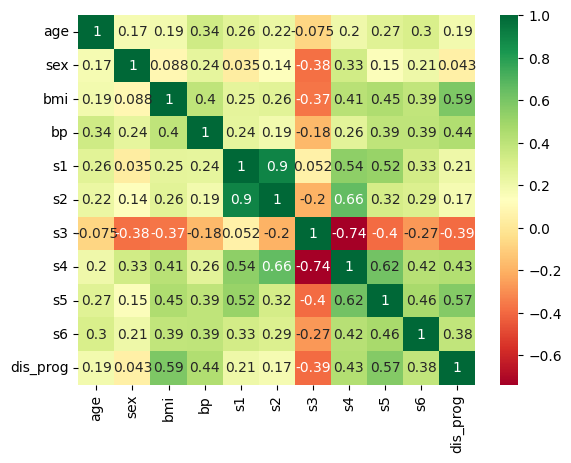

```python
sns.heatmap(diabetes.corr(), annot=True,cmap = 'RdYlGn')
```

**scatter plot**

Creating a scatter plot between the independent ('bmi") variable and target variable (dis_prog)

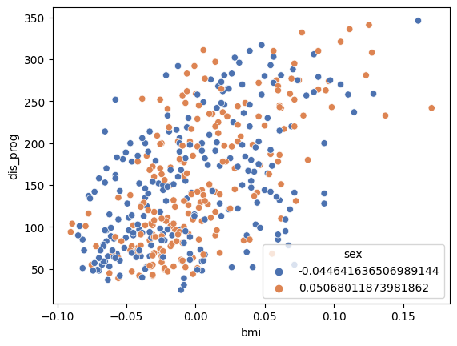

```python
sns.scatterplot(data = diabetes, x = "bmi", y = "dis_prog", hue = "sex", palette= "deep")
```

**distribution plot**

to visualize the spread of the dependent feature

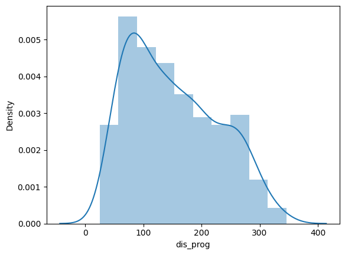

```python
import warnings
warnings.filterwarnings("ignore")
sns.distplot(diabetes["dis_prog"])
```

**splitting the data**

```python
X = np.array(diabetes["bmi"]).reshape(-1,1) # X is the feature
y = np.array(diabetes["dis_prog"])
```

```python
# Split the data into training and testing sets
X_train, X_test, y_train, y_test = train_test_split(X,y ,test_size=0.2, random_state=0)
```

**plotting the data**

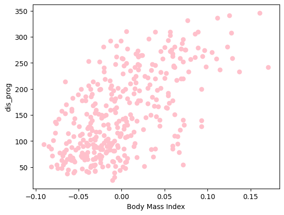

```python
plt.scatter(X_train,y_train,color = 'pink',label = "Training_data")
plt.xlabel('Body Mass Index')
plt.ylabel('dis_prog')
```

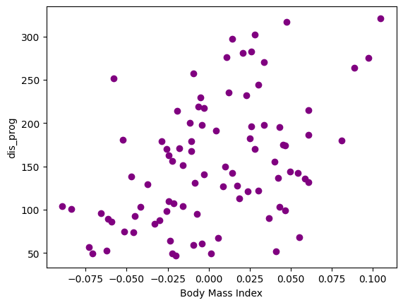

```python
plt.scatter(X_test,y_test,color = "purple",label = "Test data")
plt.xlabel('Body Mass Index')
plt.ylabel('dis_prog')
```

**model fitting**

```python
model = LinearRegression()
model.fit(X_train,y_train)
```

```
LinearRegression()
```

**making predictions**

```python
y_test_pred = model.predict(X_test)
y_train_pred = model.predict(X_train)
```

**Finding the coefficients Intercepts of the trained model**

```python
m = model.coef_
b = model.intercept_
print("Regression coefficients of the model are: ", m)
print("Regression Intercept is: ", b)
```

```
Regression coefficients of the model are:  [981.65543614]
Regression Intercept is:  152.28824927379569
```

**Calculating the loss on training and test data using mean squared error**

```python
train_loss = mean_squared_error(y_train, y_train_pred)
test_loss = mean_squared_error(y_test, y_test_pred)

print("Train Loss: {:.2f}".format(train_loss))
print("Test Loss: {:.2f}".format(test_loss))
```

```
Train Loss: 3827.82
Test Loss: 4150.68
```

**Plotting the Prediction line Vs actual data**

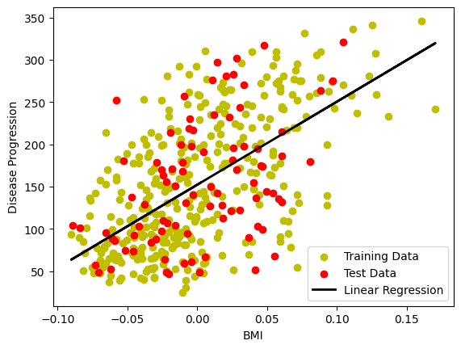

```python
# Plot the training data, test data, and the model
plt.scatter(X_train, y_train, color='y', label='Training Data')
plt.scatter(X_test, y_test, color='red', label='Test Data')
plt.plot(X_train, y_train_pred, color='black', linewidth=2, label='Linear Regression')
plt.xlabel('BMI')
plt.ylabel('Disease Progression')
plt.legend()
plt.show()
```

```python
# The mean absolute error
print("Mean absolue error: %.2f" %metrics.mean_absolute_error(y_test, y_test_pred))

# Root Mean Square Error
print("RMSE of the model is: %.2f" %np.sqrt(test_loss))

# Accuracy of the model
print("R-Squared of the model: %.2f" %model.score(X,y))
```

```
Mean absolue error: 52.94
RMSE of the model is: 64.43
R-Squared of the model: 0.34
```

**Present your solution.**

After running the univariate linear regression on the diabetes dataset using BMI as the independent variable and disease progression as the dependent variable, here are the results:

Take-aways from the fit:

The slope of the linear regression model is 981.66, indicating that as BMI increases, there is a positive relationship with disease progression. In other words, higher BMI tends to be associated with higher disease progression.

The intercept of 152.29 represents the estimated disease progression when the BMI is zero. However, this value might not have practical meaning in the context of the dataset.

The train loss of 3827.82 and test loss of 4150.68 indicate the mean squared error (MSE) of the model's predictions. The lower the MSE, the better the fit of the model to the data.

The scatter plots visualize the distribution of the training and test data points, with the linear regression line representing the model's predictions. The yellow dots represent the training data, and the red dots represent the test data.

Overall, the fit of the model seems decent, but it may not be the best. The MSE values are relatively high, indicating that there is still room for improvement in predicting the disease progression based solely on BMI. It is recommended to further explore the dataset, consider additional independent variables, or try more advanced regression techniques to potentially improve the model's performance.